# Risk Factor Analysis

## Outcome Variable

**Outcome Variable:** pers_wast

## Predictor Variables

**Intervention Variable:** enstunt

**Adjustment Set:**

unadjusted

## Stratifying Variables

The analysis was stratified on these variable(s):

- agecat
- studyid
- country

## Data Summary

| agecat | studyid | country | enstunt | pers_wast | n_cell | n |
| --- | --- | --- | --- | --- | --- | --- |
| 0-24 months | CMC-V-BCS-2002 | INDIA | 0 | 0 | 281 | 373 |
| 0-24 months | CMC-V-BCS-2002 | INDIA | 0 | 1 | 15 | 373 |
| 0-24 months | CMC-V-BCS-2002 | INDIA | 1 | 0 | 69 | 373 |
| 0-24 months | CMC-V-BCS-2002 | INDIA | 1 | 1 | 8 | 373 |
| 0-24 months | CMIN | BANGLADESH | 0 | 0 | 152 | 257 |
| 0-24 months | CMIN | BANGLADESH | 0 | 1 | 9 | 257 |
| 0-24 months | CMIN | BANGLADESH | 1 | 0 | 85 | 257 |
| 0-24 months | CMIN | BANGLADESH | 1 | 1 | 11 | 257 |
| 0-24 months | COHORTS | GUATEMALA | 0 | 0 | 826 | 1056 |
| 0-24 months | COHORTS | GUATEMALA | 0 | 1 | 22 | 1056 |
| 0-24 months | COHORTS | GUATEMALA | 1 | 0 | 194 | 1056 |
| 0-24 months | COHORTS | GUATEMALA | 1 | 1 | 14 | 1056 |
| 0-24 months | COHORTS | INDIA | 0 | 0 | 4663 | 5705 |
| 0-24 months | COHORTS | INDIA | 0 | 1 | 447 | 5705 |
| 0-24 months | COHORTS | INDIA | 1 | 0 | 492 | 5705 |
| 0-24 months | COHORTS | INDIA | 1 | 1 | 103 | 5705 |
| 0-24 months | COHORTS | PHILIPPINES | 0 | 0 | 2524 | 2811 |
| 0-24 months | COHORTS | PHILIPPINES | 0 | 1 | 127 | 2811 |
| 0-24 months | COHORTS | PHILIPPINES | 1 | 0 | 143 | 2811 |
| 0-24 months | COHORTS | PHILIPPINES | 1 | 1 | 17 | 2811 |
| 0-24 months | CONTENT | PERU | 0 | 0 | 195 | 215 |
| 0-24 months | CONTENT | PERU | 0 | 1 | 0 | 215 |
| 0-24 months | CONTENT | PERU | 1 | 0 | 20 | 215 |
| 0-24 months | CONTENT | PERU | 1 | 1 | 0 | 215 |
| 0-24 months | EE | PAKISTAN | 0 | 0 | 195 | 377 |
| 0-24 months | EE | PAKISTAN | 0 | 1 | 16 | 377 |
| 0-24 months | EE | PAKISTAN | 1 | 0 | 149 | 377 |
| 0-24 months | EE | PAKISTAN | 1 | 1 | 17 | 377 |
| 0-24 months | GMS-Nepal | NEPAL | 0 | 0 | 434 | 597 |
| 0-24 months | GMS-Nepal | NEPAL | 0 | 1 | 66 | 597 |

[output cut: 310 more lines]

The following strata were considered:

- agecat: 0-24 months, studyid: CMC-V-BCS-2002, country: INDIA
- agecat: 0-24 months, studyid: CMIN, country: BANGLADESH
- agecat: 0-24 months, studyid: COHORTS, country: GUATEMALA
- agecat: 0-24 months, studyid: COHORTS, country: INDIA
- agecat: 0-24 months, studyid: COHORTS, country: PHILIPPINES
- agecat: 0-24 months, studyid: CONTENT, country: PERU
- agecat: 0-24 months, studyid: EE, country: PAKISTAN
- agecat: 0-24 months, studyid: GMS-Nepal, country: NEPAL
- agecat: 0-24 months, studyid: Guatemala BSC, country: GUATEMALA
- agecat: 0-24 months, studyid: iLiNS-Zinc, country: BURKINA FASO
- agecat: 0-24 months, studyid: IRC, country: INDIA
- agecat: 0-24 months, studyid: JiVitA-3, country: BANGLADESH
- agecat: 0-24 months, studyid: JiVitA-4, country: BANGLADESH
- agecat: 0-24 months, studyid: Keneba, country: GAMBIA
- agecat: 0-24 months, studyid: LCNI-5, country: MALAWI
- agecat: 0-24 months, studyid: MAL-ED, country: BANGLADESH
- agecat: 0-24 months, studyid: MAL-ED, country: BRAZIL
- agecat: 0-24 months, studyid: MAL-ED, country: INDIA
- agecat: 0-24 months, studyid: MAL-ED, country: NEPAL
- agecat: 0-24 months, studyid: MAL-ED, country: PERU
- agecat: 0-24 months, studyid: MAL-ED, country: SOUTH AFRICA
- agecat: 0-24 months, studyid: MAL-ED, country: TANZANIA, UNITED REPUBLIC OF
- agecat: 0-24 months, studyid: NIH-Birth, country: BANGLADESH
- agecat: 0-24 months, studyid: NIH-Crypto, country: BANGLADESH
- agecat: 0-24 months, studyid: PROBIT, country: BELARUS
- agecat: 0-24 months, studyid: PROVIDE, country: BANGLADESH
- agecat: 0-24 months, studyid: ResPak, country: PAKISTAN
- agecat: 0-24 months, studyid: SAS-CompFeed, country: INDIA
- agecat: 0-24 months, studyid: SAS-FoodSuppl, country: INDIA
- agecat: 0-24 months, studyid: TanzaniaChild2, country: TANZANIA, UNITED REPUBLIC OF
- agecat: 0-24 months, studyid: ZVITAMBO, country: ZIMBABWE
- agecat: 0-6 months, studyid: CMC-V-BCS-2002, country: INDIA
- agecat: 0-6 months, studyid: CMIN, country: BANGLADESH
- agecat: 0-6 months, studyid: COHORTS, country: PHILIPPINES
- agecat: 0-6 months, studyid: CONTENT, country: PERU
- agecat: 0-6 months, studyid: EE, country: PAKISTAN
- agecat: 0-6 months, studyid: GMS-Nepal, country: NEPAL
- agecat: 0-6 months, studyid: IRC, country: INDIA
- agecat: 0-6 months, studyid: JiVitA-3, country: BANGLADESH
- agecat: 0-6 months, studyid: Keneba, country: GAMBIA
- agecat: 0-6 months, studyid: MAL-ED, country: BANGLADESH
- agecat: 0-6 months, studyid: MAL-ED, country: BRAZIL
- agecat: 0-6 months, studyid: MAL-ED, country: INDIA
- agecat: 0-6 months, studyid: MAL-ED, country: NEPAL
- agecat: 0-6 months, studyid: MAL-ED, country: PERU
- agecat: 0-6 months, studyid: MAL-ED, country: SOUTH AFRICA
- agecat: 0-6 months, studyid: MAL-ED, country: TANZANIA, UNITED REPUBLIC OF
- agecat: 0-6 months, studyid: NIH-Birth, country: BANGLADESH
- agecat: 0-6 months, studyid: NIH-Crypto, country: BANGLADESH
- agecat: 0-6 months, studyid: PROBIT, country: BELARUS
- agecat: 0-6 months, studyid: PROVIDE, country: BANGLADESH
- agecat: 0-6 months, studyid: ResPak, country: PAKISTAN
- agecat: 0-6 months, studyid: TanzaniaChild2, country: TANZANIA, UNITED REPUBLIC OF
- agecat: 0-6 months, studyid: ZVITAMBO, country: ZIMBABWE
- agecat: 6-24 months, studyid: CMC-V-BCS-2002, country: INDIA
- agecat: 6-24 months, studyid: CMIN, country: BANGLADESH
- agecat: 6-24 months, studyid: COHORTS, country: GUATEMALA
- agecat: 6-24 months, studyid: COHORTS, country: INDIA
- agecat: 6-24 months, studyid: COHORTS, country: PHILIPPINES
- agecat: 6-24 months, studyid: CONTENT, country: PERU
- agecat: 6-24 months, studyid: EE, country: PAKISTAN
- agecat: 6-24 months, studyid: GMS-Nepal, country: NEPAL
- agecat: 6-24 months, studyid: Guatemala BSC, country: GUATEMALA
- agecat: 6-24 months, studyid: iLiNS-Zinc, country: BURKINA FASO
- agecat: 6-24 months, studyid: IRC, country: INDIA
- agecat: 6-24 months, studyid: JiVitA-3, country: BANGLADESH
- agecat: 6-24 months, studyid: JiVitA-4, country: BANGLADESH
- agecat: 6-24 months, studyid: Keneba, country: GAMBIA
- agecat: 6-24 months, studyid: LCNI-5, country: MALAWI
- agecat: 6-24 months, studyid: MAL-ED, country: BANGLADESH
- agecat: 6-24 months, studyid: MAL-ED, country: BRAZIL
- agecat: 6-24 months, studyid: MAL-ED, country: INDIA
- agecat: 6-24 months, studyid: MAL-ED, country: NEPAL
- agecat: 6-24 months, studyid: MAL-ED, country: PERU
- agecat: 6-24 months, studyid: MAL-ED, country: SOUTH AFRICA
- agecat: 6-24 months, studyid: MAL-ED, country: TANZANIA, UNITED REPUBLIC OF
- agecat: 6-24 months, studyid: NIH-Birth, country: BANGLADESH
- agecat: 6-24 months, studyid: NIH-Crypto, country: BANGLADESH
- agecat: 6-24 months, studyid: PROBIT, country: BELARUS
- agecat: 6-24 months, studyid: PROVIDE, country: BANGLADESH
- agecat: 6-24 months, studyid: ResPak, country: PAKISTAN
- agecat: 6-24 months, studyid: SAS-CompFeed, country: INDIA
- agecat: 6-24 months, studyid: SAS-FoodSuppl, country: INDIA
- agecat: 6-24 months, studyid: TanzaniaChild2, country: TANZANIA, UNITED REPUBLIC OF
- agecat: 6-24 months, studyid: ZVITAMBO, country: ZIMBABWE

### Dropped Strata

Some strata were dropped due to rare outcomes:

- agecat: 0-24 months, studyid: CONTENT, country: PERU
- agecat: 0-24 months, studyid: Guatemala BSC, country: GUATEMALA
- agecat: 0-24 months, studyid: LCNI-5, country: MALAWI
- agecat: 0-24 months, studyid: MAL-ED, country: BANGLADESH
- agecat: 0-24 months, studyid: MAL-ED, country: BRAZIL
- agecat: 0-24 months, studyid: MAL-ED, country: INDIA
- agecat: 0-24 months, studyid: MAL-ED, country: NEPAL
- agecat: 0-24 months, studyid: MAL-ED, country: PERU
- agecat: 0-24 months, studyid: MAL-ED, country: SOUTH AFRICA
- agecat: 0-24 months, studyid: MAL-ED, country: TANZANIA, UNITED REPUBLIC OF
- agecat: 0-24 months, studyid: PROBIT, country: BELARUS
- agecat: 0-24 months, studyid: PROVIDE, country: BANGLADESH
- agecat: 0-24 months, studyid: TanzaniaChild2, country: TANZANIA, UNITED REPUBLIC OF
- agecat: 0-6 months, studyid: CMIN, country: BANGLADESH
- agecat: 0-6 months, studyid: COHORTS, country: PHILIPPINES
- agecat: 0-6 months, studyid: CONTENT, country: PERU
- agecat: 0-6 months, studyid: JiVitA-3, country: BANGLADESH
- agecat: 0-6 months, studyid: MAL-ED, country: BANGLADESH
- agecat: 0-6 months, studyid: MAL-ED, country: BRAZIL
- agecat: 0-6 months, studyid: MAL-ED, country: INDIA
- agecat: 0-6 months, studyid: MAL-ED, country: NEPAL
- agecat: 0-6 months, studyid: MAL-ED, country: PERU
- agecat: 0-6 months, studyid: MAL-ED, country: SOUTH AFRICA
- agecat: 0-6 months, studyid: MAL-ED, country: TANZANIA, UNITED REPUBLIC OF
- agecat: 0-6 months, studyid: NIH-Birth, country: BANGLADESH
- agecat: 0-6 months, studyid: NIH-Crypto, country: BANGLADESH
- agecat: 0-6 months, studyid: PROBIT, country: BELARUS
- agecat: 0-6 months, studyid: PROVIDE, country: BANGLADESH
- agecat: 0-6 months, studyid: TanzaniaChild2, country: TANZANIA, UNITED REPUBLIC OF
- agecat: 0-6 months, studyid: ZVITAMBO, country: ZIMBABWE
- agecat: 6-24 months, studyid: CONTENT, country: PERU
- agecat: 6-24 months, studyid: Guatemala BSC, country: GUATEMALA
- agecat: 6-24 months, studyid: LCNI-5, country: MALAWI
- agecat: 6-24 months, studyid: MAL-ED, country: BANGLADESH
- agecat: 6-24 months, studyid: MAL-ED, country: BRAZIL
- agecat: 6-24 months, studyid: MAL-ED, country: INDIA
- agecat: 6-24 months, studyid: MAL-ED, country: NEPAL
- agecat: 6-24 months, studyid: MAL-ED, country: PERU
- agecat: 6-24 months, studyid: MAL-ED, country: SOUTH AFRICA
- agecat: 6-24 months, studyid: MAL-ED, country: TANZANIA, UNITED REPUBLIC OF
- agecat: 6-24 months, studyid: PROBIT, country: BELARUS
- agecat: 6-24 months, studyid: PROVIDE, country: BANGLADESH
- agecat: 6-24 months, studyid: TanzaniaChild2, country: TANZANIA, UNITED REPUBLIC OF

## Methods Detail

We’re interested in the causal parameters $E[Y_a]$ for all values of $a \in \mathcal{A}$. These parameters represent the mean outcome if, possibly contrary to fact, we intervened to set all units to have $A=a$. Under the randomization and positivity assumptions, these are identified by the statistical parameters $\psi_a=E_W[E_{Y|A,W}(Y|A=a,W)]$. In addition, we’re interested in the mean of $Y$, $E[Y]$ under no intervention (the observed mean). We will estimate these parameters by using SuperLearner to fit the relevant likelihood factors – $E_{Y|A,W}(Y|A=a,W)$ and $p(A=a|W)$, and then updating our likelihood fit using a joint TMLE.

For unadjusted analyses ($W=\{\}$), initial likelihoods were estimated using Lrnr_glm to estimate the simple $E(Y|A)$ and Lrnr_mean to estimate $p(A)$. For adjusted analyses, a small library containing Lrnr_glmnet, Lrnr_xgboost, and Lrnr_mean was used.

Having estimated these parameters, we will then use the delta method to estimate relative risks and attributable risks relative to a prespecified baseline level of $A$.

# Results Detail

## Results Plots

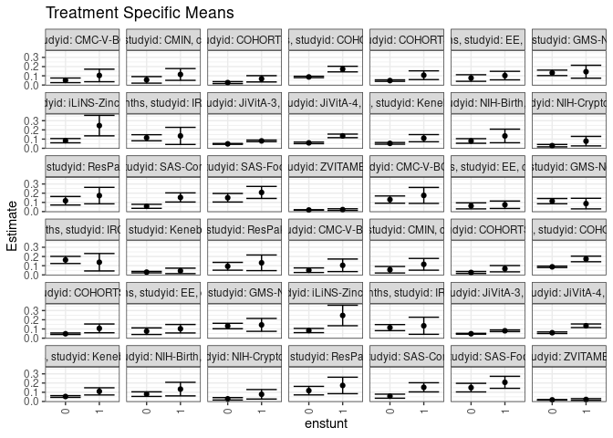

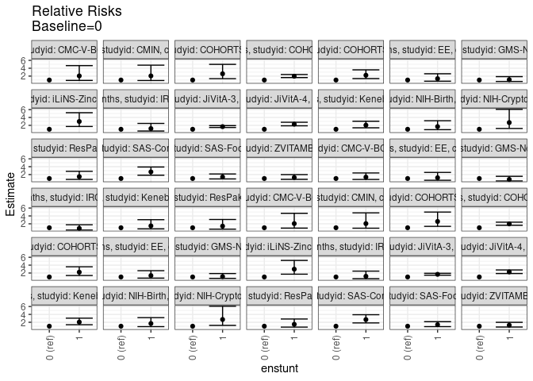

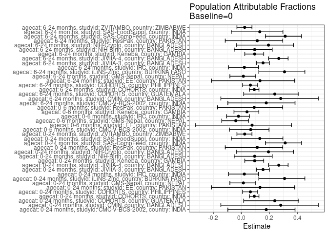

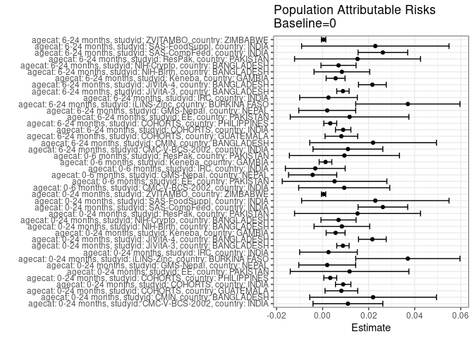

## Results Table

### Parameter: TSM

| agecat | studyid | country | intervention_level | baseline_level | estimate | ci_lower | ci_upper |
| --- | --- | --- | --- | --- | --- | --- | --- |
| 0-24 months | CMC-V-BCS-2002 | INDIA | 0 | NA | 0.0506757 | 0.0256554 | 0.0756960 |
| 0-24 months | CMC-V-BCS-2002 | INDIA | 1 | NA | 0.1038961 | 0.0356521 | 0.1721401 |
| 0-24 months | CMIN | BANGLADESH | 0 | NA | 0.0559006 | 0.0203458 | 0.0914555 |
| 0-24 months | CMIN | BANGLADESH | 1 | NA | 0.1145833 | 0.0507432 | 0.1784234 |
| 0-24 months | COHORTS | GUATEMALA | 0 | NA | 0.0259434 | 0.0152390 | 0.0366478 |
| 0-24 months | COHORTS | GUATEMALA | 1 | NA | 0.0673077 | 0.0332415 | 0.1013739 |
| 0-24 months | COHORTS | INDIA | 0 | NA | 0.0874755 | 0.0797284 | 0.0952227 |
| 0-24 months | COHORTS | INDIA | 1 | NA | 0.1731092 | 0.1427066 | 0.2035119 |
| 0-24 months | COHORTS | PHILIPPINES | 0 | NA | 0.0479065 | 0.0397752 | 0.0560377 |
| 0-24 months | COHORTS | PHILIPPINES | 1 | NA | 0.1062500 | 0.0584929 | 0.1540071 |
| 0-24 months | EE | PAKISTAN | 0 | NA | 0.0758294 | 0.0400627 | 0.1115960 |
| 0-24 months | EE | PAKISTAN | 1 | NA | 0.1024096 | 0.0562268 | 0.1485924 |
| 0-24 months | GMS-Nepal | NEPAL | 0 | NA | 0.1320000 | 0.1023056 | 0.1616944 |
| 0-24 months | GMS-Nepal | NEPAL | 1 | NA | 0.1443299 | 0.0743364 | 0.2143234 |
| 0-24 months | iLiNS-Zinc | BURKINA FASO | 0 | NA | 0.0828173 | 0.0596913 | 0.1059434 |
| 0-24 months | iLiNS-Zinc | BURKINA FASO | 1 | NA | 0.2466844 | 0.1353014 | 0.3580673 |
| 0-24 months | IRC | INDIA | 0 | NA | 0.1145251 | 0.0814977 | 0.1475526 |
| 0-24 months | IRC | INDIA | 1 | NA | 0.1346154 | 0.0417340 | 0.2274968 |
| 0-24 months | JiVitA-3 | BANGLADESH | 0 | NA | 0.0480007 | 0.0435099 | 0.0524915 |
| 0-24 months | JiVitA-3 | BANGLADESH | 1 | NA | 0.0802498 | 0.0713956 | 0.0891040 |
| 0-24 months | JiVitA-4 | BANGLADESH | 0 | NA | 0.0590572 | 0.0505310 | 0.0675834 |
| 0-24 months | JiVitA-4 | BANGLADESH | 1 | NA | 0.1348837 | 0.1154032 | 0.1543643 |
| 0-24 months | Keneba | GAMBIA | 0 | NA | 0.0536852 | 0.0442605 | 0.0631099 |
| 0-24 months | Keneba | GAMBIA | 1 | NA | 0.1097561 | 0.0706866 | 0.1488256 |
| 0-24 months | NIH-Birth | BANGLADESH | 0 | NA | 0.0796460 | 0.0546630 | 0.1046291 |
| 0-24 months | NIH-Birth | BANGLADESH | 1 | NA | 0.1341463 | 0.0603118 | 0.2079809 |
| 0-24 months | NIH-Crypto | BANGLADESH | 0 | NA | 0.0287081 | 0.0156287 | 0.0417876 |
| 0-24 months | NIH-Crypto | BANGLADESH | 1 | NA | 0.0776699 | 0.0259454 | 0.1293945 |
| 0-24 months | ResPak | PAKISTAN | 0 | NA | 0.1176471 | 0.0713782 | 0.1639159 |
| 0-24 months | ResPak | PAKISTAN | 1 | NA | 0.1739130 | 0.0843039 | 0.2635222 |

[output cut: 54 more lines]

### Parameter: E(Y)

| agecat | studyid | country | intervention_level | baseline_level | estimate | ci_lower | ci_upper |
| --- | --- | --- | --- | --- | --- | --- | --- |
| 0-24 months | CMC-V-BCS-2002 | INDIA | NA | NA | 0.0616622 | 0.0372186 | 0.0861058 |
| 0-24 months | CMIN | BANGLADESH | NA | NA | 0.0778210 | 0.0450051 | 0.1106369 |
| 0-24 months | COHORTS | GUATEMALA | NA | NA | 0.0340909 | 0.0231410 | 0.0450408 |
| 0-24 months | COHORTS | INDIA | NA | NA | 0.0964067 | 0.0887472 | 0.1040661 |
| 0-24 months | COHORTS | PHILIPPINES | NA | NA | 0.0512273 | 0.0430760 | 0.0593786 |
| 0-24 months | EE | PAKISTAN | NA | NA | 0.0875332 | 0.0589672 | 0.1160991 |
| 0-24 months | GMS-Nepal | NEPAL | NA | NA | 0.1340034 | 0.1066544 | 0.1613523 |
| 0-24 months | iLiNS-Zinc | BURKINA FASO | NA | NA | 0.1198322 | 0.0943748 | 0.1452897 |
| 0-24 months | IRC | INDIA | NA | NA | 0.1170732 | 0.0859146 | 0.1482317 |
| 0-24 months | JiVitA-3 | BANGLADESH | NA | NA | 0.0568247 | 0.0527145 | 0.0609348 |
| 0-24 months | JiVitA-4 | BANGLADESH | NA | NA | 0.0806665 | 0.0720540 | 0.0892791 |
| 0-24 months | Keneba | GAMBIA | NA | NA | 0.0593290 | 0.0499611 | 0.0686968 |
| 0-24 months | NIH-Birth | BANGLADESH | NA | NA | 0.0880150 | 0.0639627 | 0.1120673 |
| 0-24 months | NIH-Crypto | BANGLADESH | NA | NA | 0.0356164 | 0.0221630 | 0.0490699 |
| 0-24 months | ResPak | PAKISTAN | NA | NA | 0.1328125 | 0.0911588 | 0.1744662 |
| 0-24 months | SAS-CompFeed | INDIA | NA | NA | 0.0834553 | 0.0601989 | 0.1067118 |
| 0-24 months | SAS-FoodSuppl | INDIA | NA | NA | 0.1733333 | 0.1349698 | 0.2116969 |
| 0-24 months | ZVITAMBO | ZIMBABWE | NA | NA | 0.0176341 | 0.0149910 | 0.0202771 |
| 0-6 months | CMC-V-BCS-2002 | INDIA | NA | NA | 0.1396648 | 0.1037072 | 0.1756225 |
| 0-6 months | EE | PAKISTAN | NA | NA | 0.0673854 | 0.0418419 | 0.0929290 |
| 0-6 months | GMS-Nepal | NEPAL | NA | NA | 0.1093474 | 0.0836377 | 0.1350572 |
| 0-6 months | IRC | INDIA | NA | NA | 0.1592040 | 0.1233945 | 0.1950135 |
| 0-6 months | Keneba | GAMBIA | NA | NA | 0.0308068 | 0.0233159 | 0.0382978 |
| 0-6 months | ResPak | PAKISTAN | NA | NA | 0.1028807 | 0.0646041 | 0.1411572 |
| 6-24 months | CMC-V-BCS-2002 | INDIA | NA | NA | 0.0616622 | 0.0372186 | 0.0861058 |
| 6-24 months | CMIN | BANGLADESH | NA | NA | 0.0778210 | 0.0450051 | 0.1106369 |
| 6-24 months | COHORTS | GUATEMALA | NA | NA | 0.0340909 | 0.0231410 | 0.0450408 |
| 6-24 months | COHORTS | INDIA | NA | NA | 0.0964067 | 0.0887472 | 0.1040661 |
| 6-24 months | COHORTS | PHILIPPINES | NA | NA | 0.0512273 | 0.0430760 | 0.0593786 |
| 6-24 months | EE | PAKISTAN | NA | NA | 0.0875332 | 0.0589672 | 0.1160991 |
| 6-24 months | GMS-Nepal | NEPAL | NA | NA | 0.1340034 | 0.1066544 | 0.1613523 |
| 6-24 months | iLiNS-Zinc | BURKINA FASO | NA | NA | 0.1198322 | 0.0943748 | 0.1452897 |
| 6-24 months | IRC | INDIA | NA | NA | 0.1170732 | 0.0859146 | 0.1482317 |
| 6-24 months | JiVitA-3 | BANGLADESH | NA | NA | 0.0568247 | 0.0527145 | 0.0609348 |
| 6-24 months | JiVitA-4 | BANGLADESH | NA | NA | 0.0806665 | 0.0720540 | 0.0892791 |
| 6-24 months | Keneba | GAMBIA | NA | NA | 0.0593290 | 0.0499611 | 0.0686968 |
| 6-24 months | NIH-Birth | BANGLADESH | NA | NA | 0.0880150 | 0.0639627 | 0.1120673 |
| 6-24 months | NIH-Crypto | BANGLADESH | NA | NA | 0.0356164 | 0.0221630 | 0.0490699 |
| 6-24 months | ResPak | PAKISTAN | NA | NA | 0.1328125 | 0.0911588 | 0.1744662 |
| 6-24 months | SAS-CompFeed | INDIA | NA | NA | 0.0834553 | 0.0601989 | 0.1067118 |
| 6-24 months | SAS-FoodSuppl | INDIA | NA | NA | 0.1733333 | 0.1349698 | 0.2116969 |
| 6-24 months | ZVITAMBO | ZIMBABWE | NA | NA | 0.0176341 | 0.0149910 | 0.0202771 |

### Parameter: RR

| agecat | studyid | country | intervention_level | baseline_level | estimate | ci_lower | ci_upper |
| --- | --- | --- | --- | --- | --- | --- | --- |
| 0-24 months | CMC-V-BCS-2002 | INDIA | 0 | 0 | 1.0000000 | 1.0000000 | 1.000000 |
| 0-24 months | CMC-V-BCS-2002 | INDIA | 1 | 0 | 2.0502165 | 0.9014289 | 4.663027 |
| 0-24 months | CMIN | BANGLADESH | 0 | 0 | 1.0000000 | 1.0000000 | 1.000000 |
| 0-24 months | CMIN | BANGLADESH | 1 | 0 | 2.0497685 | 0.8800068 | 4.774453 |
| 0-24 months | COHORTS | GUATEMALA | 0 | 0 | 1.0000000 | 1.0000000 | 1.000000 |
| 0-24 months | COHORTS | GUATEMALA | 1 | 0 | 2.5944056 | 1.3503435 | 4.984613 |
| 0-24 months | COHORTS | INDIA | 0 | 0 | 1.0000000 | 1.0000000 | 1.000000 |
| 0-24 months | COHORTS | INDIA | 1 | 0 | 1.9789446 | 1.6255887 | 2.409110 |
| 0-24 months | COHORTS | PHILIPPINES | 0 | 0 | 1.0000000 | 1.0000000 | 1.000000 |
| 0-24 months | COHORTS | PHILIPPINES | 1 | 0 | 2.2178642 | 1.3717492 | 3.585875 |
| 0-24 months | EE | PAKISTAN | 0 | 0 | 1.0000000 | 1.0000000 | 1.000000 |
| 0-24 months | EE | PAKISTAN | 1 | 0 | 1.3505271 | 0.7032306 | 2.593635 |
| 0-24 months | GMS-Nepal | NEPAL | 0 | 0 | 1.0000000 | 1.0000000 | 1.000000 |
| 0-24 months | GMS-Nepal | NEPAL | 1 | 0 | 1.0934083 | 0.6406380 | 1.866174 |
| 0-24 months | iLiNS-Zinc | BURKINA FASO | 0 | 0 | 1.0000000 | 1.0000000 | 1.000000 |
| 0-24 months | iLiNS-Zinc | BURKINA FASO | 1 | 0 | 2.9786559 | 1.7044845 | 5.205322 |
| 0-24 months | IRC | INDIA | 0 | 0 | 1.0000000 | 1.0000000 | 1.000000 |
| 0-24 months | IRC | INDIA | 1 | 0 | 1.1754221 | 0.5564423 | 2.482948 |
| 0-24 months | JiVitA-3 | BANGLADESH | 0 | 0 | 1.0000000 | 1.0000000 | 1.000000 |
| 0-24 months | JiVitA-3 | BANGLADESH | 1 | 0 | 1.6718459 | 1.4503915 | 1.927113 |
| 0-24 months | JiVitA-4 | BANGLADESH | 0 | 0 | 1.0000000 | 1.0000000 | 1.000000 |
| 0-24 months | JiVitA-4 | BANGLADESH | 1 | 0 | 2.2839504 | 1.8757196 | 2.781028 |
| 0-24 months | Keneba | GAMBIA | 0 | 0 | 1.0000000 | 1.0000000 | 1.000000 |
| 0-24 months | Keneba | GAMBIA | 1 | 0 | 2.0444399 | 1.3746797 | 3.040515 |
| 0-24 months | NIH-Birth | BANGLADESH | 0 | 0 | 1.0000000 | 1.0000000 | 1.000000 |
| 0-24 months | NIH-Birth | BANGLADESH | 1 | 0 | 1.6842818 | 0.8938906 | 3.173549 |
| 0-24 months | NIH-Crypto | BANGLADESH | 0 | 0 | 1.0000000 | 1.0000000 | 1.000000 |
| 0-24 months | NIH-Crypto | BANGLADESH | 1 | 0 | 2.7055016 | 1.2073171 | 6.062814 |
| 0-24 months | ResPak | PAKISTAN | 0 | 0 | 1.0000000 | 1.0000000 | 1.000000 |
| 0-24 months | ResPak | PAKISTAN | 1 | 0 | 1.4782609 | 0.7731129 | 2.826567 |

[output cut: 54 more lines]

### Parameter: PAR

| agecat | studyid | country | intervention_level | baseline_level | estimate | ci_lower | ci_upper |
| --- | --- | --- | --- | --- | --- | --- | --- |
| 0-24 months | CMC-V-BCS-2002 | INDIA | 0 | NA | 0.0109865 | -0.0041772 | 0.0261502 |
| 0-24 months | CMIN | BANGLADESH | 0 | NA | 0.0219204 | -0.0055961 | 0.0494369 |
| 0-24 months | COHORTS | GUATEMALA | 0 | NA | 0.0081475 | 0.0010443 | 0.0152507 |
| 0-24 months | COHORTS | INDIA | 0 | NA | 0.0089311 | 0.0055892 | 0.0122730 |
| 0-24 months | COHORTS | PHILIPPINES | 0 | NA | 0.0033209 | 0.0005185 | 0.0061232 |
| 0-24 months | EE | PAKISTAN | 0 | NA | 0.0117038 | -0.0140512 | 0.0374587 |
| 0-24 months | GMS-Nepal | NEPAL | 0 | NA | 0.0020034 | -0.0103556 | 0.0143623 |
| 0-24 months | iLiNS-Zinc | BURKINA FASO | 0 | NA | 0.0370149 | 0.0143815 | 0.0596483 |
| 0-24 months | IRC | INDIA | 0 | NA | 0.0025480 | -0.0099714 | 0.0150675 |
| 0-24 months | JiVitA-3 | BANGLADESH | 0 | NA | 0.0088240 | 0.0061368 | 0.0115111 |
| 0-24 months | JiVitA-4 | BANGLADESH | 0 | NA | 0.0216093 | 0.0155866 | 0.0276321 |
| 0-24 months | Keneba | GAMBIA | 0 | NA | 0.0056438 | 0.0015435 | 0.0097441 |
| 0-24 months | NIH-Birth | BANGLADESH | 0 | NA | 0.0083690 | -0.0037161 | 0.0204540 |
| 0-24 months | NIH-Crypto | BANGLADESH | 0 | NA | 0.0069083 | -0.0007205 | 0.0145371 |
| 0-24 months | ResPak | PAKISTAN | 0 | NA | 0.0151654 | -0.0121888 | 0.0425197 |
| 0-24 months | SAS-CompFeed | INDIA | 0 | NA | 0.0261689 | 0.0153894 | 0.0369484 |
| 0-24 months | SAS-FoodSuppl | INDIA | 0 | NA | 0.0228909 | -0.0091168 | 0.0548985 |
| 0-24 months | ZVITAMBO | ZIMBABWE | 0 | NA | 0.0004228 | -0.0005263 | 0.0013718 |
| 0-6 months | CMC-V-BCS-2002 | INDIA | 0 | NA | 0.0093831 | -0.0104007 | 0.0291670 |
| 0-6 months | EE | PAKISTAN | 0 | NA | 0.0051845 | -0.0175373 | 0.0279063 |
| 0-6 months | GMS-Nepal | NEPAL | 0 | NA | -0.0043368 | -0.0148050 | 0.0061315 |
| 0-6 months | IRC | INDIA | 0 | NA | -0.0031892 | -0.0161740 | 0.0097956 |
| 0-6 months | Keneba | GAMBIA | 0 | NA | 0.0012528 | -0.0014934 | 0.0039991 |
| 0-6 months | ResPak | PAKISTAN | 0 | NA | 0.0094741 | -0.0144300 | 0.0333782 |
| 6-24 months | CMC-V-BCS-2002 | INDIA | 0 | NA | 0.0109865 | -0.0041772 | 0.0261502 |
| 6-24 months | CMIN | BANGLADESH | 0 | NA | 0.0219204 | -0.0055961 | 0.0494369 |
| 6-24 months | COHORTS | GUATEMALA | 0 | NA | 0.0081475 | 0.0010443 | 0.0152507 |
| 6-24 months | COHORTS | INDIA | 0 | NA | 0.0089311 | 0.0055892 | 0.0122730 |
| 6-24 months | COHORTS | PHILIPPINES | 0 | NA | 0.0033209 | 0.0005185 | 0.0061232 |
| 6-24 months | EE | PAKISTAN | 0 | NA | 0.0117038 | -0.0140512 | 0.0374587 |
| 6-24 months | GMS-Nepal | NEPAL | 0 | NA | 0.0020034 | -0.0103556 | 0.0143623 |
| 6-24 months | iLiNS-Zinc | BURKINA FASO | 0 | NA | 0.0370149 | 0.0143815 | 0.0596483 |
| 6-24 months | IRC | INDIA | 0 | NA | 0.0025480 | -0.0099714 | 0.0150675 |
| 6-24 months | JiVitA-3 | BANGLADESH | 0 | NA | 0.0088240 | 0.0061368 | 0.0115111 |
| 6-24 months | JiVitA-4 | BANGLADESH | 0 | NA | 0.0216093 | 0.0155866 | 0.0276321 |
| 6-24 months | Keneba | GAMBIA | 0 | NA | 0.0056438 | 0.0015435 | 0.0097441 |
| 6-24 months | NIH-Birth | BANGLADESH | 0 | NA | 0.0083690 | -0.0037161 | 0.0204540 |
| 6-24 months | NIH-Crypto | BANGLADESH | 0 | NA | 0.0069083 | -0.0007205 | 0.0145371 |
| 6-24 months | ResPak | PAKISTAN | 0 | NA | 0.0151654 | -0.0121888 | 0.0425197 |
| 6-24 months | SAS-CompFeed | INDIA | 0 | NA | 0.0261689 | 0.0153894 | 0.0369484 |
| 6-24 months | SAS-FoodSuppl | INDIA | 0 | NA | 0.0228909 | -0.0091168 | 0.0548985 |
| 6-24 months | ZVITAMBO | ZIMBABWE | 0 | NA | 0.0004228 | -0.0005263 | 0.0013718 |

### Parameter: PAF

| agecat | studyid | country | intervention_level | baseline_level | estimate | ci_lower | ci_upper |
| --- | --- | --- | --- | --- | --- | --- | --- |
| 0-24 months | CMC-V-BCS-2002 | INDIA | 0 | NA | 0.1781727 | -0.0961308 | 0.3838326 |
| 0-24 months | CMIN | BANGLADESH | 0 | NA | 0.2816770 | -0.1460941 | 0.5497857 |
| 0-24 months | COHORTS | GUATEMALA | 0 | NA | 0.2389937 | 0.0173535 | 0.4106420 |
| 0-24 months | COHORTS | INDIA | 0 | NA | 0.0926401 | 0.0579652 | 0.1260387 |
| 0-24 months | COHORTS | PHILIPPINES | 0 | NA | 0.0648262 | 0.0094245 | 0.1171293 |
| 0-24 months | EE | PAKISTAN | 0 | NA | 0.1337067 | -0.2128627 | 0.3812457 |
| 0-24 months | GMS-Nepal | NEPAL | 0 | NA | 0.0149500 | -0.0816959 | 0.1029610 |
| 0-24 months | iLiNS-Zinc | BURKINA FASO | 0 | NA | 0.3088893 | 0.1252364 | 0.4539851 |
| 0-24 months | IRC | INDIA | 0 | NA | 0.0217644 | -0.0911067 | 0.1229595 |
| 0-24 months | JiVitA-3 | BANGLADESH | 0 | NA | 0.1552839 | 0.1073638 | 0.2006315 |
| 0-24 months | JiVitA-4 | BANGLADESH | 0 | NA | 0.2678848 | 0.1949152 | 0.3342407 |
| 0-24 months | Keneba | GAMBIA | 0 | NA | 0.0951272 | 0.0248848 | 0.1603098 |
| 0-24 months | NIH-Birth | BANGLADESH | 0 | NA | 0.0950857 | -0.0508086 | 0.2207240 |
| 0-24 months | NIH-Crypto | BANGLADESH | 0 | NA | 0.1939639 | -0.0356867 | 0.3726924 |
| 0-24 months | ResPak | PAKISTAN | 0 | NA | 0.1141869 | -0.1148128 | 0.2961464 |
| 0-24 months | SAS-CompFeed | INDIA | 0 | NA | 0.3135678 | 0.1721194 | 0.4308490 |
| 0-24 months | SAS-FoodSuppl | INDIA | 0 | NA | 0.1320626 | -0.0718853 | 0.2972053 |
| 0-24 months | ZVITAMBO | ZIMBABWE | 0 | NA | 0.0239757 | -0.0312323 | 0.0762280 |
| 0-6 months | CMC-V-BCS-2002 | INDIA | 0 | NA | 0.0671831 | -0.0849314 | 0.1979701 |
| 0-6 months | EE | PAKISTAN | 0 | NA | 0.0769378 | -0.3285022 | 0.3586433 |
| 0-6 months | GMS-Nepal | NEPAL | 0 | NA | -0.0396604 | -0.1395689 | 0.0514888 |
| 0-6 months | IRC | INDIA | 0 | NA | -0.0200321 | -0.1048596 | 0.0582827 |
| 0-6 months | Keneba | GAMBIA | 0 | NA | 0.0406677 | -0.0521823 | 0.1253241 |
| 0-6 months | ResPak | PAKISTAN | 0 | NA | 0.0920879 | -0.1701059 | 0.2955301 |
| 6-24 months | CMC-V-BCS-2002 | INDIA | 0 | NA | 0.1781727 | -0.0961308 | 0.3838326 |
| 6-24 months | CMIN | BANGLADESH | 0 | NA | 0.2816770 | -0.1460941 | 0.5497857 |
| 6-24 months | COHORTS | GUATEMALA | 0 | NA | 0.2389937 | 0.0173535 | 0.4106420 |
| 6-24 months | COHORTS | INDIA | 0 | NA | 0.0926401 | 0.0579652 | 0.1260387 |
| 6-24 months | COHORTS | PHILIPPINES | 0 | NA | 0.0648262 | 0.0094245 | 0.1171293 |
| 6-24 months | EE | PAKISTAN | 0 | NA | 0.1337067 | -0.2128627 | 0.3812457 |
| 6-24 months | GMS-Nepal | NEPAL | 0 | NA | 0.0149500 | -0.0816959 | 0.1029610 |
| 6-24 months | iLiNS-Zinc | BURKINA FASO | 0 | NA | 0.3088893 | 0.1252364 | 0.4539851 |
| 6-24 months | IRC | INDIA | 0 | NA | 0.0217644 | -0.0911067 | 0.1229595 |
| 6-24 months | JiVitA-3 | BANGLADESH | 0 | NA | 0.1552839 | 0.1073638 | 0.2006315 |
| 6-24 months | JiVitA-4 | BANGLADESH | 0 | NA | 0.2678848 | 0.1949152 | 0.3342407 |
| 6-24 months | Keneba | GAMBIA | 0 | NA | 0.0951272 | 0.0248848 | 0.1603098 |
| 6-24 months | NIH-Birth | BANGLADESH | 0 | NA | 0.0950857 | -0.0508086 | 0.2207240 |
| 6-24 months | NIH-Crypto | BANGLADESH | 0 | NA | 0.1939639 | -0.0356867 | 0.3726924 |
| 6-24 months | ResPak | PAKISTAN | 0 | NA | 0.1141869 | -0.1148128 | 0.2961464 |
| 6-24 months | SAS-CompFeed | INDIA | 0 | NA | 0.3135678 | 0.1721194 | 0.4308490 |
| 6-24 months | SAS-FoodSuppl | INDIA | 0 | NA | 0.1320626 | -0.0718853 | 0.2972053 |
| 6-24 months | ZVITAMBO | ZIMBABWE | 0 | NA | 0.0239757 | -0.0312323 | 0.0762280 |